# Ptychodera Cisreg Development: Re-analysis of Amphioxus

Alberto Perez-Posada

4/22/2023

## About

In this markdown, we will do a re-analysis of the transcriptome of *Branchiostoma lanceolatum* (Marletaz et al., 2018).

## Load libraries

```r
library(tidyverse)
library(stringr)
library(BiocGenerics)
library(EDASeq)
library(DESeq2)
library(tximport)
library(limma)
library(ComplexHeatmap)
library(circlize)
library(RColorBrewer)
```

## Load functions

```r
source("code/r_code/r_functions/sourcefolder.R")

sourceFolder(
  "code/r_code/r_functions",
  recursive = TRUE
  )

sourceFolder(
  "code/r_code/r_general",
  recursive = TRUE
  )
```

## Load data

We will load a sample table with all the information of each developmental transcriptome, in a similar way we did with Ptychodera.

```r
samplesdir <-
  "outputs/comparative/reanalysis/blan/kallisto/abundances/"

sampleTable <-
  read.table(
    "outputs/comparative/reanalysis/blan/kallisto/abundances/table_runs_samples_blan_RNA_2.tsv",
    header=F
  )

sampleTable <-
  merge(
    sampleTable,
    as.data.frame(c(list.dirs(samplesdir,full.names = F)[-1])),
    by=1
    )

colnames(sampleTable) <- c("sample","condition","batch")

sampleTable$batch <-
  factor(sampleTable$batch, levels = unique(sort(sampleTable$batch)))

sampleTable$condition <- factor(sampleTable$condition)

rownames(sampleTable) <- sampleTable[,1]
sampleTable$sample <- NULL

blan_condition_x <- sampleTable$condition
```

We will also load a dictionary between the gene ids of our mapping and the gene ids of the proteome used in comparative analyses (OMA, Orthofinder). This will be useful later in the future.

```r
bl_brala <- read.table("outputs/comparative/oma/dicts/BRALA.dct", col.names = c("value","key"))[,c(2,1)]
```

## Tximport

We load the transcriptome mapping from kallisto here using the data of the sample table:

```r
library(tximport)
files <-
  list.files(samplesdir, "h5",recursive = T, full.names = T)

names(files) <-
  list.dirs(samplesdir,full.names = F)[-c(1,28)]

blan_txi.kallisto <-
  tximport(files, type = "kallisto", txOut = TRUE)
```

```
## 1 2 3 4 5 6 7 8 9 10 11 12 13 14 15 16 17 18 19 20 21 22 23 24 25 26
```

## DGE using DESeq2

Load the transcriptome counts in a DESeq2 object:

```r
blan_ddsTxi <-
  DESeqDataSetFromTximport(
    blan_txi.kallisto,
    colData = sampleTable,
    design = ~ batch + condition
    )
```

```
## using counts and average transcript lengths from tximport
```

Relevel the factor to first developmental stage.

```r
#differential expression analysis
blan_ddsTxi$condition <-
  relevel(blan_ddsTxi$condition, ref = c("01_32cells"))
```

```r
dds_blan <- estimateSizeFactors(blan_ddsTxi)
```

```
## using 'avgTxLength' from assays(dds), correcting for library size
```

```r
nc_blan <- counts(dds_blan, normalized=TRUE)
filter <- rowSums(nc_blan >= 10) >= 2
dds_blan <- dds_blan[filter,]
rownames(dds_blan) <- gsub("_..*","", rownames(dds_blan))

dds_blan <-
  DESeq(
    dds_blan,
    parallel = T,
    BPPARAM = BiocParallel::MulticoreParam(12),
    test = "LRT",
    reduced = ~batch
    )
```

We extract the results

```r
res_blan <- results(dds_blan)
res_blan
```

[output not shown]

And we keep the significant results (p.adj < 0.1)

```r
cutoff = 0.1 # try 0.05?
signif_blan <- subset(res_blan, padj<cutoff)
signif_blan <- signif_blan[order(signif_blan$padj),]
```

We extract the variance-transformed data.

```r
# raw counts
blan_counts <- as.data.frame(counts(dds_blan))
colnames(blan_counts) <-
  paste(sampleTable$condition,sampleTable$batch,sep="_")
blan_counts <- blan_counts[,order(colnames(blan_counts))]

# vs-data
blan_vsd <- as.data.frame(assay(vst(dds_blan)))
colnames(blan_vsd) <-
  paste(sampleTable$condition,sampleTable$batch,sep="_")
blan_vsd <- blan_vsd[,order(colnames(blan_vsd))]

#vs-data of stage-specific genes
rna_blan <- blan_vsd[rownames(blan_vsd) %in% rownames(signif_blan),]
```

We calculate rows by replicates:

```r
RNA_blan <-
  data.frame(
    base::sapply(
      levels(blan_condition_x),
      rowMeans_by_repl,rna_blan
      )
  )

colnames(RNA_blan) <- sub("^X","",colnames(RNA_blan))
```

## Correlation Plot

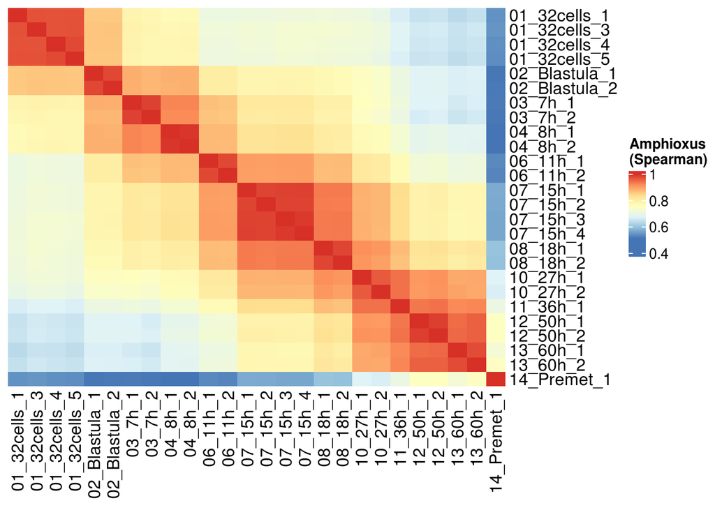

```r
blan_cor <-
  Heatmap(
    cor(blan_vsd, method = "spearman"),
    name="Amphioxus\n(Spearman)",
    cluster_rows = F,
    cluster_columns = F,
    col = colorRampPalette(rev(brewer.pal(7,"RdYlBu")))(100)
  )

draw(blan_cor)
```

## PCA plots

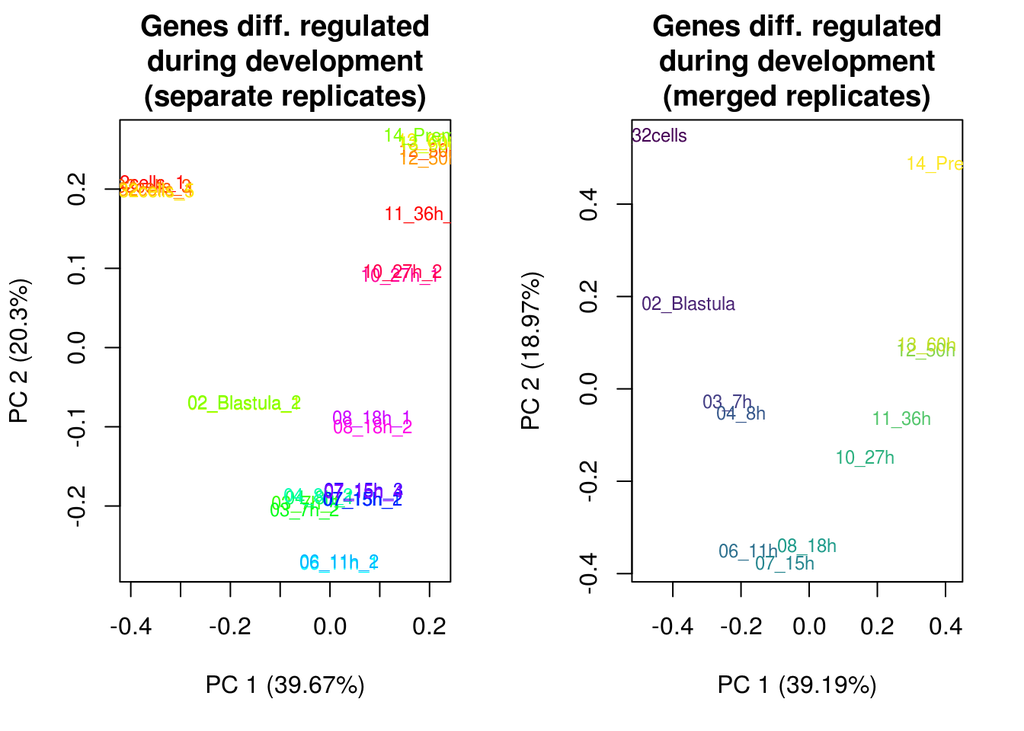

```r
par(mfrow = c(1,2))
plotPCA(as.matrix(rna_blan), col=rainbow(20), cex=0.75,main="Genes diff. regulated\nduring development\n(separate replicates)") #fix colors
plotPCA(as.matrix(RNA_blan),col=viridis::viridis(12),cex=0.75,main="Genes diff. regulated\nduring development\n(merged replicates)")
```

```r
par(mfrow = c(1,1))
```

## Clustering using hierarchical clustering

We will group the stage-specific expressed genes in groups of stage-specific coexpression using hierarchical clustering.

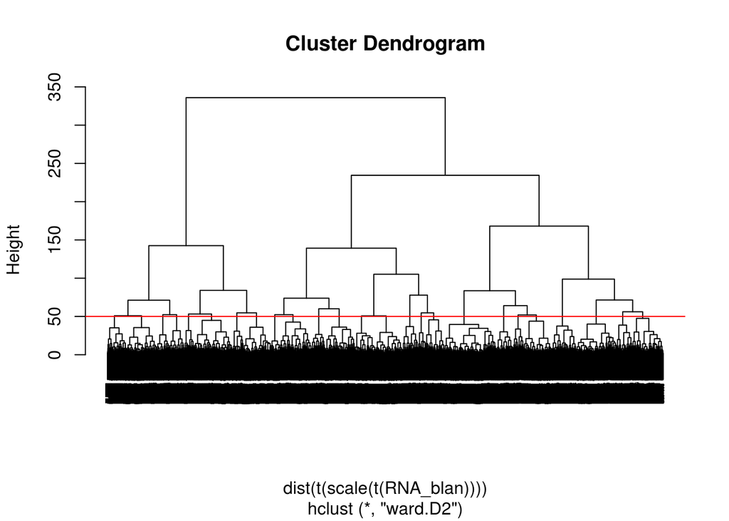

```r
blan_hc <- hclust(dist(t(scale(t(RNA_blan)))), method = "ward.D2")
plot(blan_hc,cex=0.3)
abline(50,0,col="red")
```

```r
RNA_blan$clusterID <- cutree(blan_hc, h=50)
unique(RNA_blan$clusterID)
```

```
##  [1]  1  2  3  4  5  6  7  8  9 10 11 12 13 14 15 16 17 18 19 20 21 22 23 24 25
```

Based on visual inspection, we assign new cluster names to give them new ordering:

```r
blan_newcl <-
  read.table(
    file = "outputs/comparative/reanalysis/blan/blan_newcl.tsv",
    header = FALSE,
    col.names = c("clusterID","newcl")
  )

RNA_blan$newcl <-
  translate_ids(
    x = RNA_blan$clusterID,
    dict = blan_newcl
  )

#We do not need the original hierachical cluster ids anymore
RNA_blan$clusterID <- NULL
```

And a final Heatmap for visualisation:

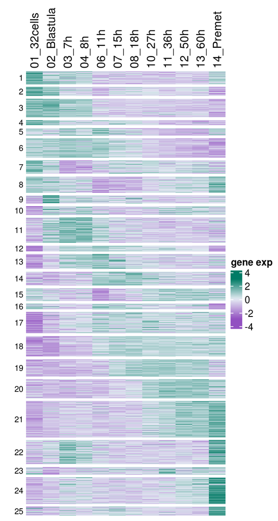

```r
set.seed(1234)
RNA_blan_viz <- RNA_blan[sample(nrow(RNA_blan),1000),]

bl_col_annot <-
  rowAnnotation(
    sample = factor(RNA_blan$newcl),
    show_annotation_name = FALSE
    )

blan_heat <-
  Heatmap(
    t(scale(t(RNA_blan_viz[,1:12]))),
    name = "gene exp",
    # left_annotation= bl_col_annot,
    row_split=RNA_blan_viz$newcl,
    show_row_names = F,
    cluster_rows=F,
    cluster_columns=F,
    row_title=NULL,
    left_annotation =
      rowAnnotation(
        cluster = anno_block(
          gp = gpar(col=NA,fill=NA),
          labels = unique(sort(RNA_blan_viz$newcl)),
          labels_gp = gpar(col = "black", cex=0.7),
          labels_just = "right",
          labels_offset = unit(1, "npc"),
          labels_rot=0
          )
        ),
  column_names_side="top",
  col = colorRampPalette(c("#9250c1","#e6ecf4","#007b66"))(20)
)

draw(blan_heat)
```

And the average expression profile of the different clusters of stage-specific genes:

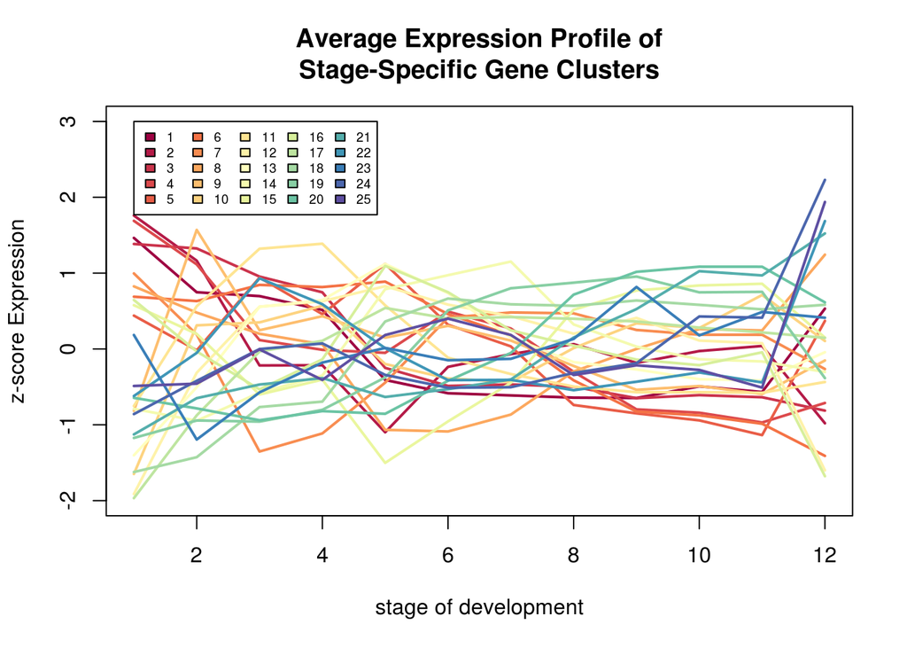

```r
blan_cl_avgs <-
  aggregate(
    t(scale(t(RNA_blan[, 1:12]))),
    by = list(cluster = RNA_blan$newcl),
    FUN = mean
  )[, -1]

blan_cl_colors <-
  colorRampPalette(colors=brewer.pal(11,"Spectral"))(25)

plot(
  0,
  xlim = c(1, 12),
  ylim = c(-2, 3),
  type = "n",
  main = "Average Expression Profile of\nStage-Specific Gene Clusters",
  xlab = "stage of development",
  ylab = "z-score Expression"
)
for (i in 1:nrow(blan_cl_avgs)) {
  lines(c(1:12),
        blan_cl_avgs[i,],
        type = "l",
        col = blan_cl_colors[i],
        lwd = 2
  )
}
legend(
  x = 1,
  y = 3,
  legend = rownames(blan_cl_avgs),
  fill = blan_cl_colors,
  ncol = 5,
  cex = 0.6
)
```

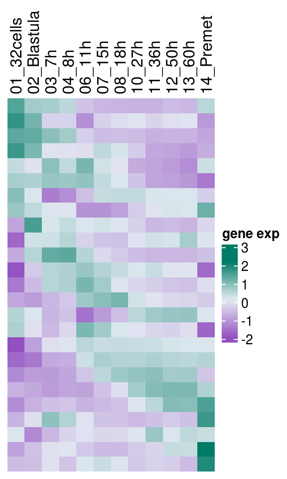

```r
blan_heat_avg <-
  Heatmap(
    blan_cl_avgs,
    name = "gene exp",
    show_row_names = F,
    cluster_rows=F,
    cluster_columns=F,
    column_names_side="top",
    col = colorRampPalette(c("#9250c1","#e6ecf4","#007b66"))(20)
  )
draw(blan_heat_avg)
```

## Save the data

We finally translate the gene ids to the same ones used in OMA:

```r
rownames(blan_counts) <- translate_ids(x = rownames(blan_counts), dict = bl_brala, return.missing = TRUE)
rownames(blan_vsd) <- translate_ids(x = rownames(blan_vsd), dict = bl_brala, return.missing = TRUE)
rownames(rna_blan) <- translate_ids(x = rownames(rna_blan), dict = bl_brala, return.missing = TRUE)
rownames(RNA_blan) <- translate_ids(x = rownames(RNA_blan), dict = bl_brala, return.missing = TRUE)
```

And we create a table of gene <-> cluster for later use in our comparative analyses:

```r
blan_cl <-
  data.frame(
    id = rownames(RNA_blan),
    cID = RNA_blan$newcl
  )
```

And we save the data for TF analysis and for pairwise comparisons:

```r
save(
  blan_counts,
  blan_vsd,
  rna_blan,
  RNA_blan,
  blan_cl,
  bl_brala,
  file = "outputs/rda/blan_reanalysis.rda"
)
```